# RSV (ABRYSVO) - Muscular weakness

OpenSourcePV

Data Lock Point: Data contains VAERS reports processed as of 2023_12_29 (Year_Month_Day). Flag NEW was defined against reports processed as of 2023_11_24.

# 1 Quantitative Signal status

## 1.1 Disproportionality

The vaccine-event combination “RSV (ABRYSVO) - Muscular weakness” was **a signal of disproportionate reporting** with an EB05 value of 2.07.

The threshold for being flagged as a signal of disproportionate reporting is an EB05>=2 meaning that there there is a 95% probability that the reporting of Muscular weakness was at least twice post exposure to RSV (ABRYSVO) than post all vaccines [1]. Under the assumption of no causality between RSV (ABRYSVO) and Muscular weakness and no bias it would have been expected to observe an EBGM of 1.

It means that the quantified causality criterion of strength of association is **met**.

*It is to be noted that the nature of the spontaneous report does not provide reliable estimates of the strength of association (whatever the choice of the disproportionality method) and that some reporting bias or difference in demographic characteristics might explain the (un)observed disproportion*.

## 1.2 Time-to-onset

The vaccine-event combination “RSV (ABRYSVO) - Muscular weakness” was **not a signal of unexpected time-to-onset distribution** with a p-value of the two-sample Kolmogorov-Smirnov test being 0.9332644 and distance between the two empirical cumulative distributions being of 11.2509975%.

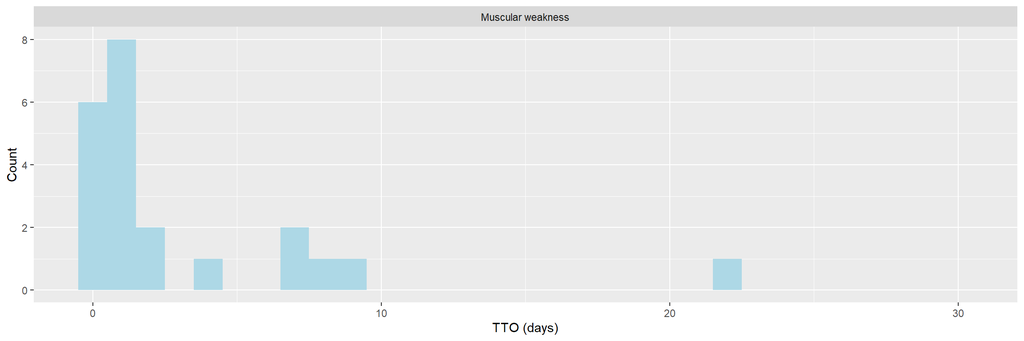

The TTO signal detection method tests if the distribution of Muscular weakness post RSV (ABRYSVO) is significantly different from the distribution of Muscular weakness post other vaccines using a two-sample Kolmogorov-Smirnov test [2]. The threshold for being flagged as a signal of unexpected time-to-onset distribution is a P-value <0.001 and a distance between the two empirical distributions larger than 20%. Under the assumption of no causality and no bias, it would have been expected that the time-to-onset distribution for “Muscular weakness” would have been the same post RSV (ABRYSVO) than post other vaccines.

It means that the quantified causality criterion of temporality is **not met**.

*It is to be noted that the nature of the spontaneous report does not provide reliable estimates of the temporal relationship between the exposure and the occurrence of the events as there is the reporting bias over time: the latter the event occurs after exposure, the less chance it has to be reported. Other biases could distort the reported time-to-onset distribution (media attention, etc.)*

## 1.3 Overall

Based on the screening of the Empirical Bayes Geometric Mean (EBGM) and the screening of the time-to-onset distribution,the vaccine-event combination “RSV (ABRYSVO) - Muscular weakness” is **considered as quantitative signal**.

# 2 Signal History

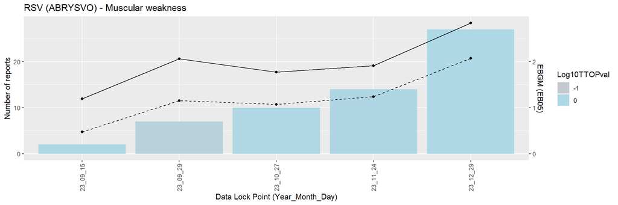

# 3 Case series

## 3.1 Seriousness

A total of 27 reports of Muscular weakness were received post exposure to RSV (ABRYSVO). Among them:

- 0 (0.0 %) were fatal cases.
- 1 (3.7 %) were life threatening cases.
- 6 (22.2 %) were hospitalized cases.
- 0 (0.0 %) were emergency room cases.
- 5 (18.5 %) were cases with disabilies.

13 new cases were received since last data refresh.

## 3.2 Demographic characteristics

27 cases of Muscular weakness post RSV (ABRYSVO) were reported in VAERS:

- Among them, there were 19 (70.4%) female cases and 8 (29.6%) male cases while the overall female:male ratio is 63:27%.
- The mean (median) age for patients presenting symptoms of Muscular weakness was 74 (72) years while the overall mean (median) age was 70 (72) years.
- The top 5 contributing US states for patients presenting symptoms of Muscular weakness were PA ( 14.8 %) , AZ ( 11.1 %) , AL ( 7.4 %) , IL ( 7.4 %) , MN ( 7.4 %) while overall the top 5 of contributing US states are NA ( 12.5 %) , CA ( 5.7 %) , OH ( 5.6 %) , PA ( 4.9 %) , NY ( 4.8 %)

# 4 Listing of the cases

Narratives can be made visible clicking on the ⊕ symbol.

|  | VAERS ID | Sex/Age (Years) | Receipt Date | Seriousness status | List of symptoms | New | SYMPTOM_TEXT |
| --- | --- | --- | --- | --- | --- | --- | --- |
| &oplus; | 2718170 | F/72 | 11/27/2023 |  | Fall, Limb discomfort, Muscular weakness | Yes | PATIENT AND HUSBAND RECEIVED RSV VACCINE 11 27 23 AT 346PM PT PRESENTED IN MOBILE SHOPPING CART PATIENT COMPLETED VACCINE CONSENT FORM AND DID NOT REPORT ANY CONCERNS OR CONTRAINDICATIONS ON THE FORM … |
| &oplus; | 2718310 | M/87 | 11/28/2023 | Life threatening &amp; Hospitalized | Angiogram cerebral, Arteriogram carotid, Blood lactic acid normal, Blood thyroid stimulating hormone normal, C-reactive protein normal, Computerised tomogram head, Full blood count normal, Guillain-Ba… | Yes | Influenza and Covid vaccine administered on 10 10 23 Patient seen in express clinic for upper respiratory infection on 10 18 23 and treated with azithromycin RSV vaccine administered on 10 24 23 Patie… |
| &oplus; | 2719812 | F/76 | 12/01/2023 | Hospitalized | Activated partial thromboplastin time, Anti factor Xa assay, Antibody test, Antineutrophil cytoplasmic antibody, Antinuclear antibody, Asthenia, Bacterial test, Balance disorder, Blood creatine phosph… | Yes | 10 12 23 Received the Abrysvo Bivalent RSV vaccine from Pfizer HF5018 into left arm at pharmacy No symptoms to report after vaccine 10 13 23 to 10 15 23 Sore left arm No other symptoms to report 10 17… |
| &oplus; | 2720223 | M/67 | 12/01/2023 |  | Muscular weakness, Pain in extremity, Pyrexia | Yes | muscle weakness fever leg pain This is a spontaneous report received from a contactable reporters Pharmacist from medical information team A 67 year old male patient received rsv vaccine protsubunit p… |
| &oplus; | 2720659 | M/86 | 12/04/2023 |  | Dysstasia, Gait disturbance, Muscular weakness | Yes | On the morning of 01 December 2023 Patient woke up and commented he had muscle weakness in his legs had difficulty rising from sitting position and was very unsteady on his feet throughout the day bal… |
| &oplus; | 2721243 | F/80 | 12/05/2023 | Hospitalized | Cerebrovascular accident, Echocardiogram normal, Electrocardiogram normal, Hemiparesis, Lipids normal, Magnetic resonance imaging head abnormal, Muscular weakness | Yes | Patient received flu vaccine in Sept 2023 and COVID RSV vaccines on the same day in Nov 2023 2 weeks after receiving the COVID RSV vaccines patient developed left arm left leg weakness and was found t… |
| &oplus; | 2721733 | F/72 | 12/07/2023 |  | Condition aggravated, Coordination abnormal, Dyspnoea, Muscular weakness, Pain, Parkinson's disease, Tremor | Yes | The patient is taking Sinemet and entacapone for Parkinsons disease She states the RSV vaccine has made her medications less effective She has muscle weakness in the legs worsening tremors difficulty … |
| &oplus; | 2724970 | F/73 | 12/18/2023 |  | Arthralgia, Dysstasia, Gait disturbance, Hypoaesthesia, Muscular weakness, Neck pain, Neuralgia, Pain in extremity, Paraesthesia, Sensory loss, Walking aid user | Yes | Initially the day after injections I was unable to stand up I couldnt grasp with my hands to pull myself up Eventually I was able to stand up and walk unsteadily with the use of a cane Severe aches an… |
| &oplus; | 2725390 | F/66 | 12/19/2023 |  | Confusional state, Dyspnoea, Electrocardiogram normal, Muscular weakness, Pain in extremity, Platelet count decreased | Yes | Pt reported about 2 hours after receiving the vaccine she experienced aching in her legs as well as weakness She then started having some shortness of breath and she thought some confusion She present… |
| &oplus; | 2725695 | M/70 | 12/19/2023 |  | Full blood count normal, Influenza virus test negative, Muscular weakness, SARS-CoV-2 test negative, Urine analysis normal | Yes | Severe musculoskeletal weakness Taking ibuprofen 48 hours after injection seeing slight improvement |

[output cut: 17 more lines]

# 5 Disclaimer

This analysis is exploratory only and authors cannot be held responsible for any decision made using these data. It is important to distinguish quantitative signals such as disproportionate reporting, unexpected time-to-onset patterns or cluster from safety signals. Only a qualitative review using multiple data source (literature, clinical trials, etc.) and multiple causality criteria assessment could qualify quantitative signals into safety signals.

# 6 References

[1] Dumouchel W. Bayesian data mining in large frequency tables, with an application to the FDA spontaneous reporting system. Am Stat 1999; 53: 177–190.

[2] Van Holle L et al, Using time‐to‐onset for detecting safety signals in spontaneous reports of adverse events following immunization: a proof-of-concept study. Pharmacoepidemiology and Drug Safety 21 (6), 603-610.